# Founders Education

Alexander Gedranovich

2016-03-03

# Introduction

The purpose of this document is to give some insights to founders education, i.e. their academic degrees and colledges or universities and how this can potentially related to the success of founded companies.

# Data Description

Data about founders education is available via Crunchbase API. At the moment there are `28996` records are aquired from Crunchbase, where each record is an entity (like one file per company, or one file per founder, etc.) Total volume of these files is `734` Mb.

Basically we have three datasets:

1. Companies – all companies from broad list of categories (i.e. including not only ‘Artificial Intelligence’ or ‘Big Data’, but also weakly related fields), 14610 records
2. Founders – all founders of companies from the previous item, 8041 records
3. Schools – all schools mentioned for all founders from the previous item, 1737 records

## Sample restriction

As a first step of data preparation we restrict the sample to the companies only from categories, strongly related to AI:

- Analytics
- Artificial Intelligence
- Big Data
- Big Data Analytics
- Bioinformatics
- Biometrics
- Biotechnology
- Business Intelligence
- Content Discovery
- Data Mining
- Data Integration
- Deep Information Technology
- Image Recognition
- Face Recognition
- Fraud Detection
- Human Resource Automation
- Machine Learning
- Marketing Automation
- Natural Language Processing
- Predictive Analytics
- Prediction Markets
- Speech Recognition
- Text Analytics

Founders and schools are restricted accordingly. After filtering we have `10536` companies and `6888` founders in the sample.

## Data Cleaning

Some fields for academic degrees of founders are reported in open format, this causes one major problem – ‘dirty text’. For instance degree type can be reported as ‘PhD’, ‘P.h.D’, ‘Ph. D.’, etc. To get value from this data it should be cleaned and organized into groups. Thus for degree type there were selected 6 types in order of level of degree:

1. Other/Unknown
2. Bachelor/Undergraduate
3. Master
4. MBA/Executive
5. Postgraduate
6. PhD/JD

The work for data cleaning is in progress, it’s done as needed for further analysis or vizualization.

# Major findings

## Number of degrees by founder

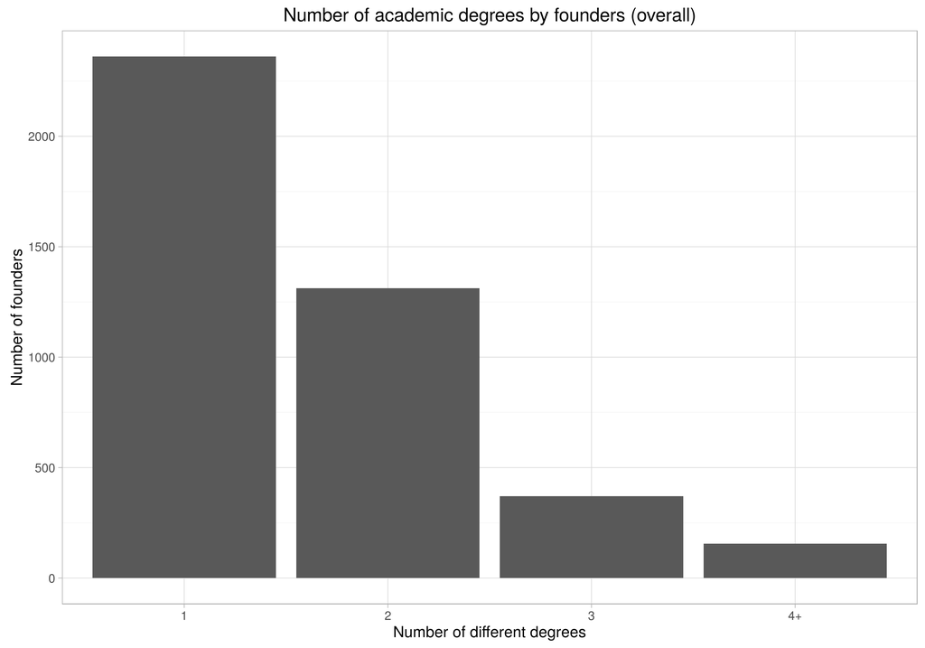

## How acadimic degrees of founders are distributed?

Most popular degree among founders is *Bachelor/Undergraduate*, folowed by *Master* and then *PhD/JD*. Good portion of founders have unknown academic degree (either not reported or nor processed correctly during clean-up). Also it’s notable that very small amount of founders have executive education.

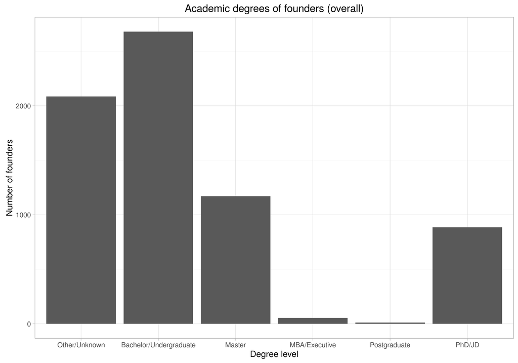

Exploration of academic degree distribution across years of companies were founded doesn’t show any significant value – *Bachelor/Undergraduate* degree was always prevalent.

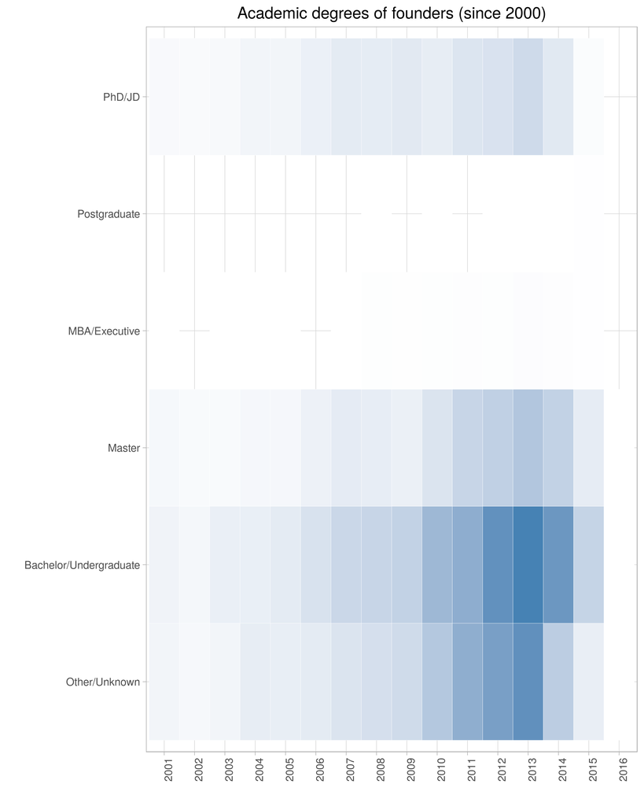

Given the fact that ~40% of founders have more than 1 degres, we took a look at maximum degree achieved by person. And here we can note proportional raise of founders with *PhD/JD* degree.

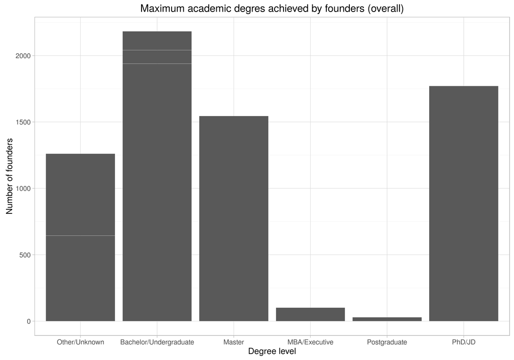

## Any trends before/after millenium?

Looking at degrees distribution before/after 2000 we can note, that portion of founders with executive education was higher before 2000 (however sample is quite small to take it as significant).

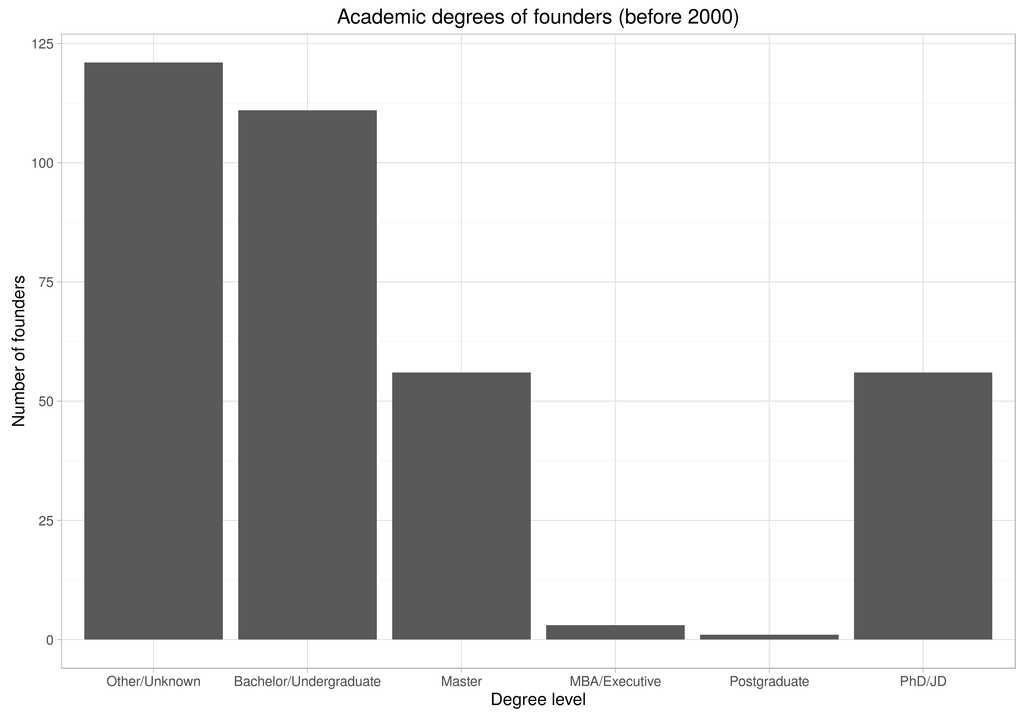

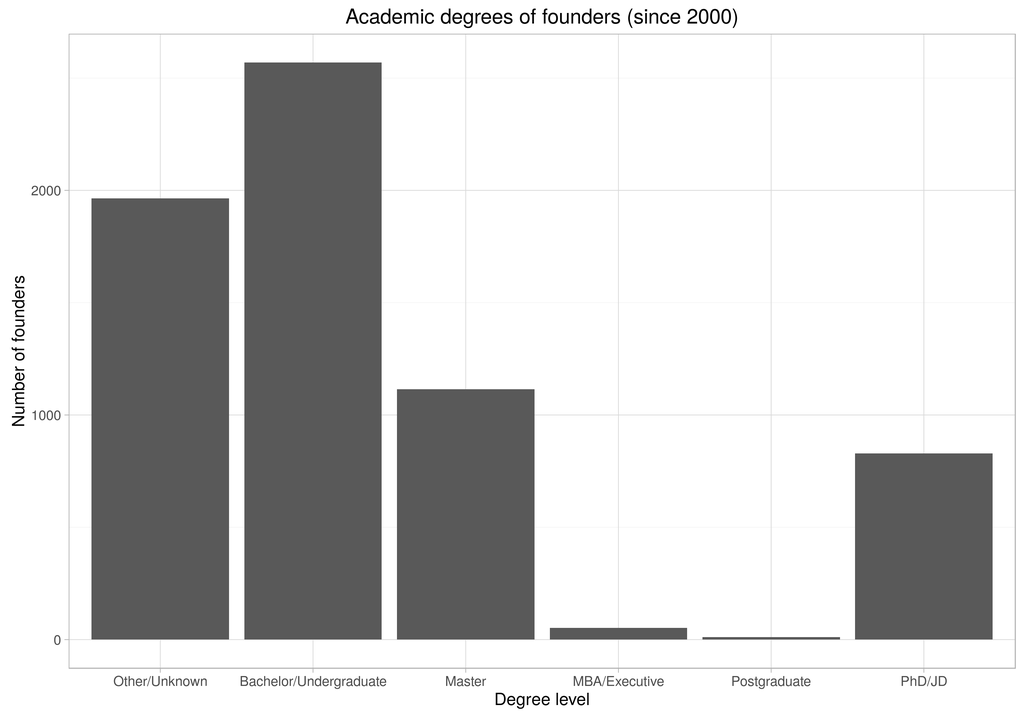

## Degree Fields

Most of the founders have degree in Computer Science or Information Technologies (including Artificial Intelligence), then goes Engineering and Robotics. Good part of founders have degree in Business, Economics or Marketing/Management.

Next popular fields are Chemistry and Biology, most probably companies founded by these founders also were related to Bio Technologies.

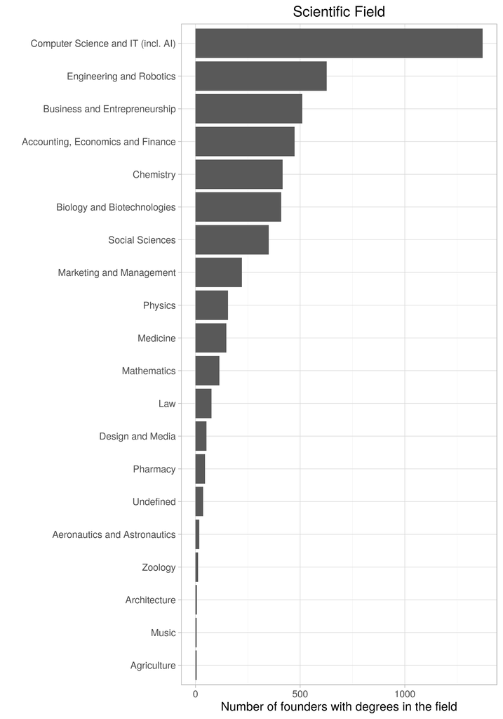

Also we can note that Computer Science as a major field for founders wasn’t dominating even two decades ago. Thus CS and Bio/Chemistry were equaly represented prior 2005, next decade CS was dominating, but staring from approximately 2010 CS is clearly superior to all other fields.

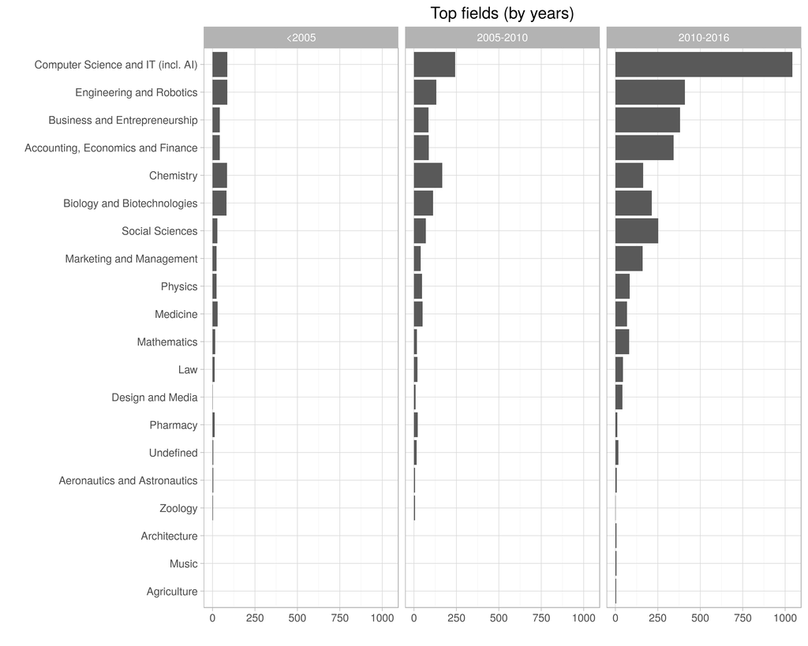

## What schools are most popular?

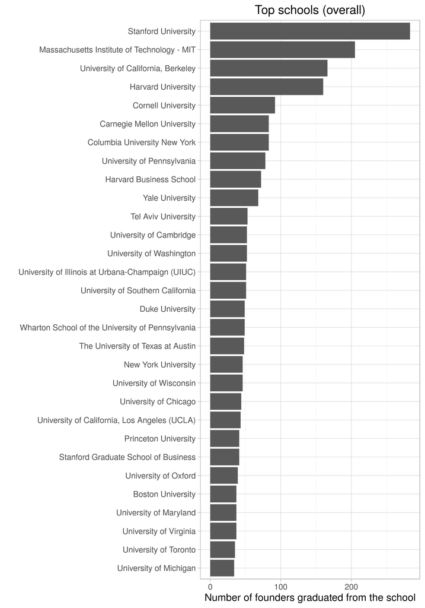

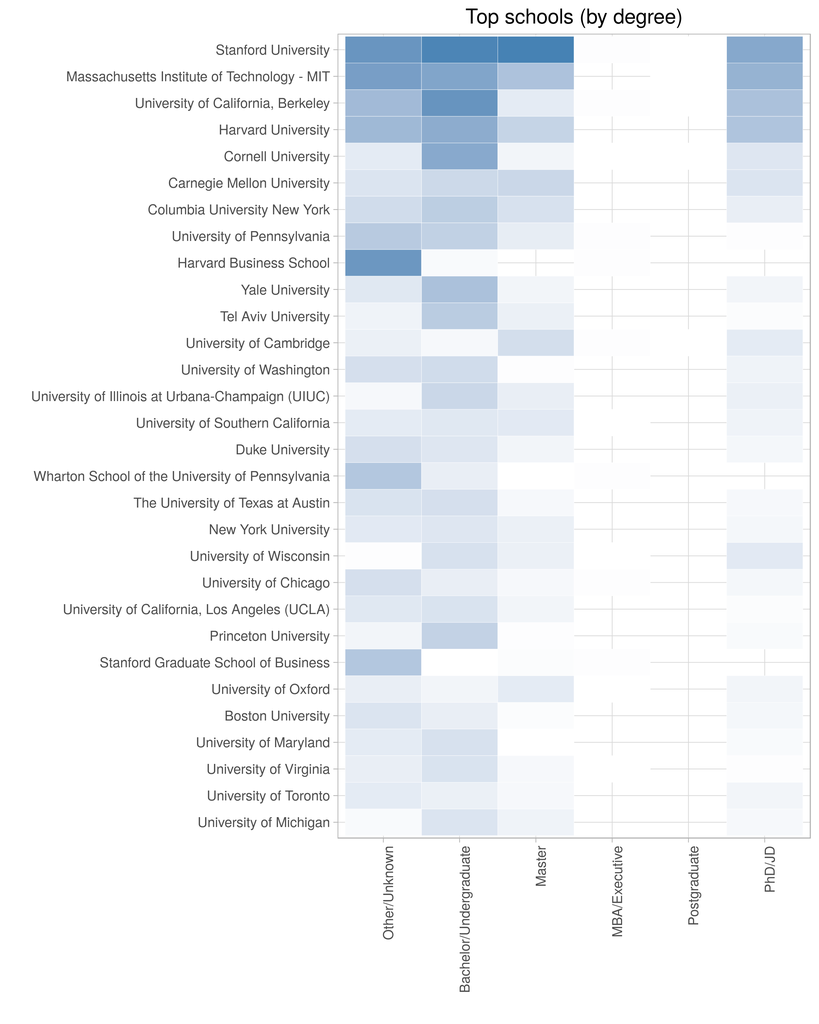

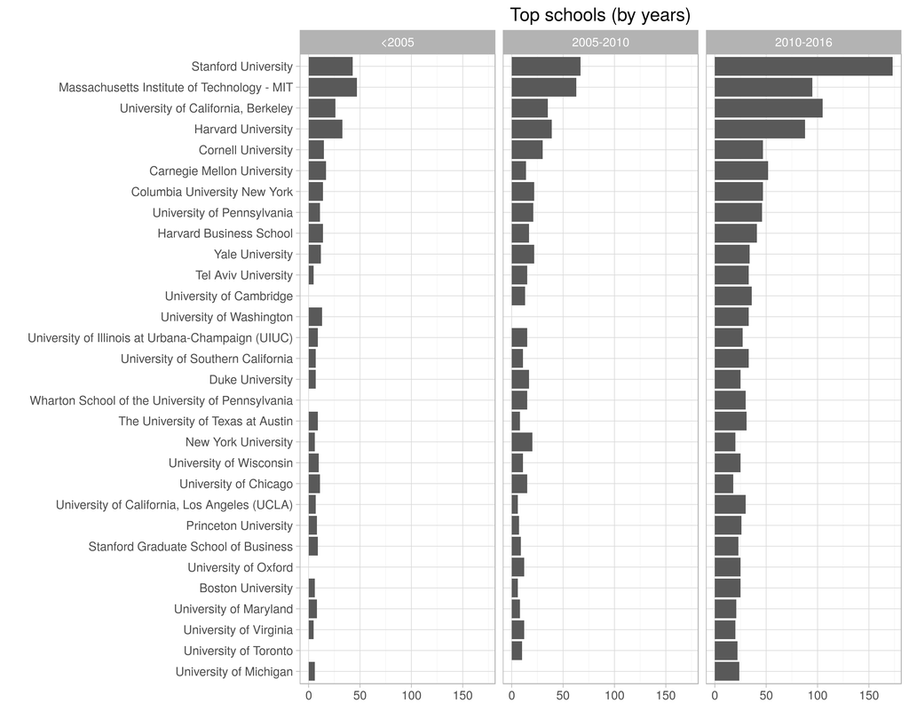

## What countries dominate?

Not surprisingly USA is dominating as host country for colleges for founders, followed by UK and Canada. Small Israel outperforms most of the countries in the sample.

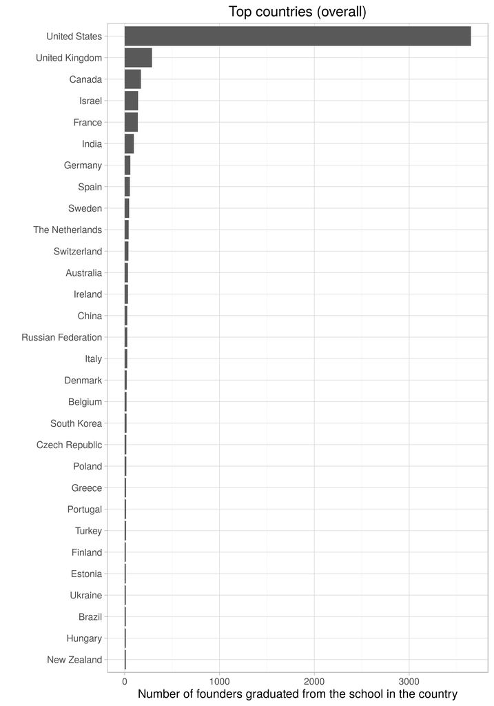

Analysis by years doesn’t add much value as US was always dominating. However number of countries with significant number of founders increased in the latest decade.

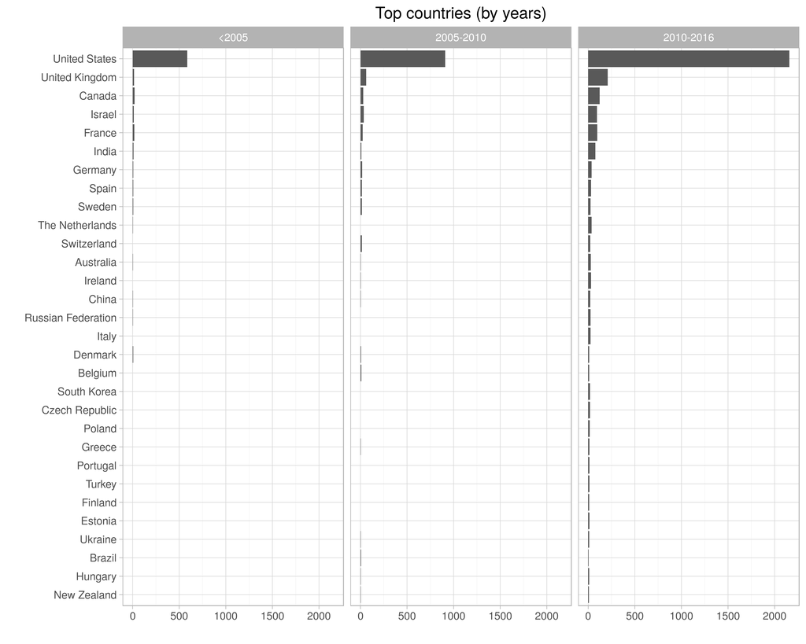

## AI vs Big Data

Let’s try to view the organization/founders in view of primary compound categories: Artificial Intelligence and Big Data.

We include this sub-categories to ‘Artificial Intelligence’:

- Artificial Intelligence
- Image Recognition
- Face Recognition
- Human Resource Automation
- Machine Learning
- Marketing Automation
- Prediction Markets
- Speech Recognition
- Text Analytics

For ‘Big Data’ we have:

- Big Data
- Big Data Analytics

First what we can see is distribution of primary category by years. If timeline is splitted by 5 years we will see that AI dominated Big Data before 2000, then Big Data took over.

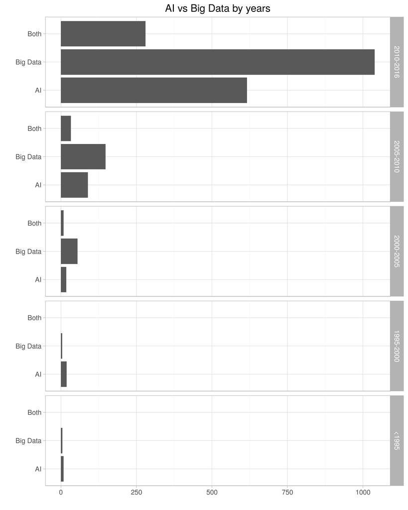

Diversity by field where founders came from is not visible – founders for AI and Big Data companies have basically the same distribution of educational fields.

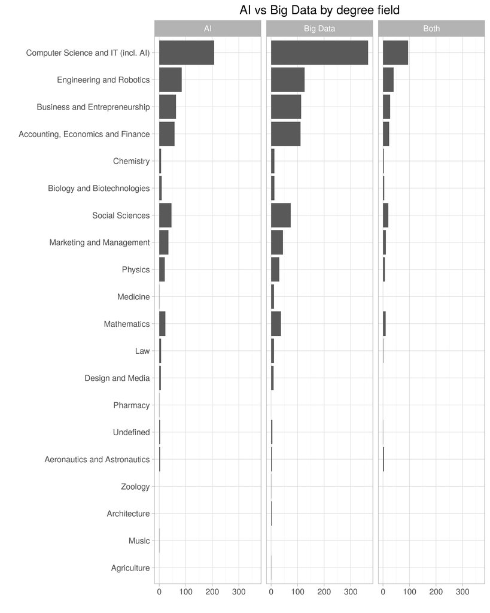

Which schools founders of AI vs Big Data companies came from? While top schools are the same we can find schools with clear specialization. Among them ‘Tel Aviv University’, UIUC, University of Wisconsin, University of Michigan (Big Data), and ‘University of Virginia’, ‘University of Toronto’ or ‘Duke University’ (AI).

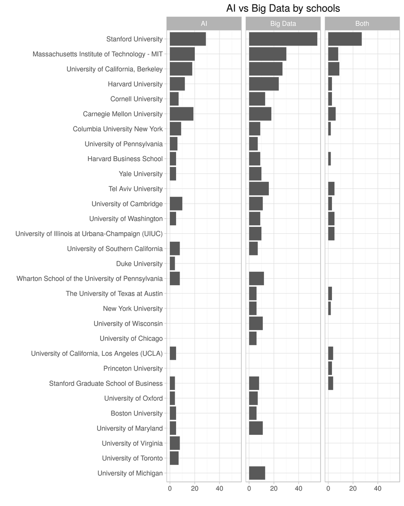

What countries founders came from? Obviously top country is USA.

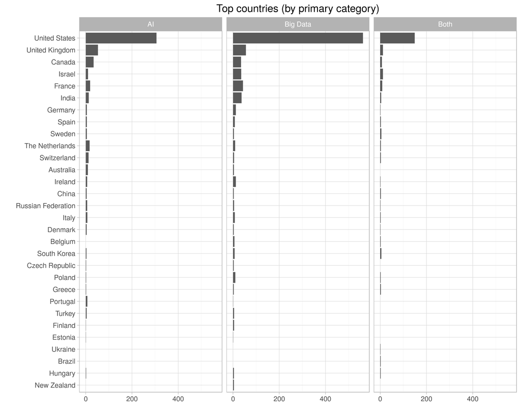

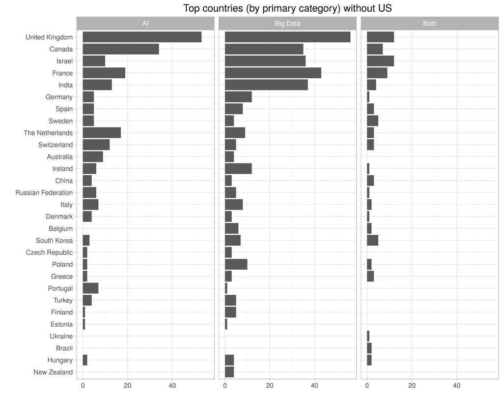